# Debt Valuation

Billy

2022-09-01

# Debt Valuation

## Valuing a Company

- The value of an asset is a function of:
  - The cash flows generated by the asset, and
  - The appropriate discount rate applied to these cash flows

A firm can be valued by:

- **Method 1**: Calculating the present value of cash flows generated by the company’s real assets
- **Method 2**: Calculating the present value of the company’s cash flows to individual securities
- Cash flows generated by a company’s real assets ultimately flow through to the shareholders debt holders of the company as dividends and interest
- Hence, the present value of cash flows generated must be equal to the value of cash flows received

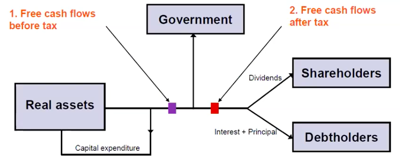

### Method 1

- The net cash flows from real assets, after reinvestment costs, are known as free cash flows
- If the company is assumed to have an infinite life, the value of the company is given by:

$$V = \sum_{t=1}^{\infty} \frac{CF_{t}}
{(1+r)^t}$$

where:

- $CF_{t}$ = free cash flow (FCF) generated by the company in period t
- r = the required rate of return (an appropriate discount rate for the company)

### Method 2

$$V = D + E$$

where:

- V = present value of cash flows generated by the company
- D = present value of cash flows generated by debt securities
- E = present value of cash flows generated by equity securities
  - Book value of equity is often higher than market value
  - Market capitalization = market value of E = number of shares x price per share

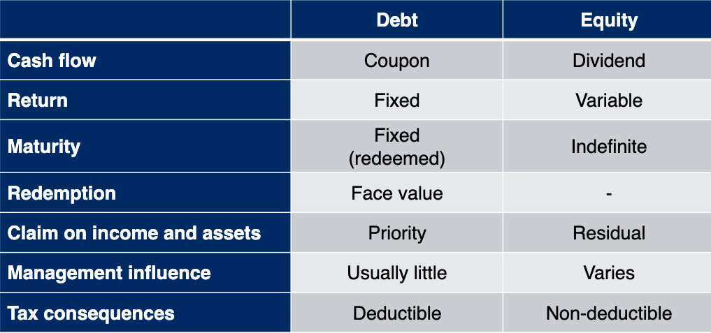

### Bonds

- Bond is a long term debt instrument that has promised future payments and maturity date
- owners of bonds receive *periodic investment payments* over the life of the bond and also get the *principal amount at maturity*
- Features of bonds
  - bond indenture
  - claims on assets and income
  - face value (or par value): nominal amount of principal borrowed; amount used to compute interest payments; typically will be repaid at end of loan.
  - coupon rate: annual interest payments expressed as percentage of bond’s face value; set by the issuer and stated on the bond indenture.
  - coupon payments: periodic interest payments determined by coupon rate.
  - maturity date: final repayment date of bond, including the principal amount borrowed.
  - yield to maturity: the market required rate of return for bonds of similar risk and maturity.
  - call provision and conversion features

### Bond terminology

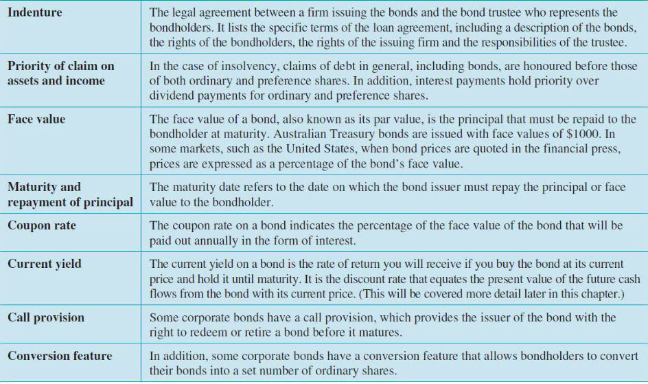

- bond ratings indicate the default risk
- Rating agencies use borrower’s financial statements, financing mix, profitability, variability of past profits…and make judgments about the quality of the firm’s management in order to determine ratings.

#### Bond ratings and default risk

- **credit risk** is the risk of default by the issuer

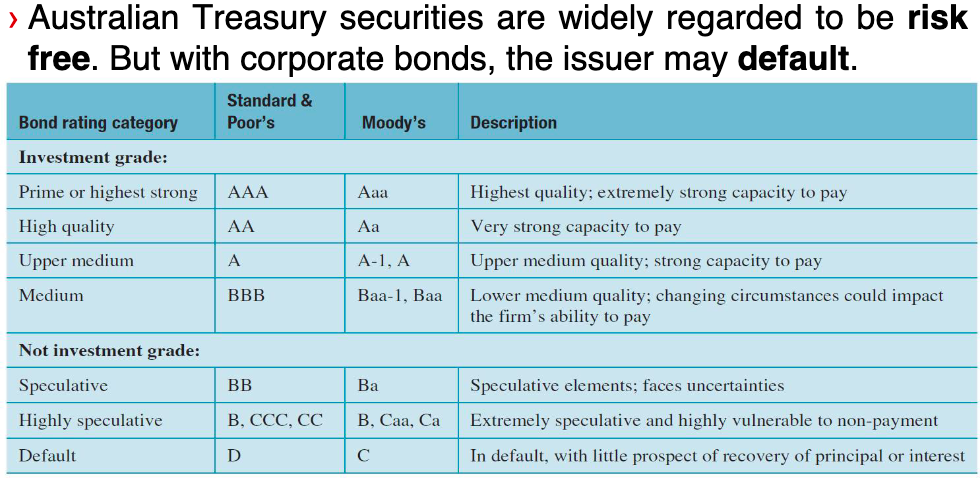

### Valuing Bonds

Bond Value = PV bonds interest (coupon) payments + PV of the bonds (face value) principal amount

Bond formula:

$$D = C [ \frac{1-(1+r_{d})^{-n}}{r_{d}}]
+ \frac{F}{(1+r_{d})^{n}}$$

where:

- D = price value of debt or equity
- C = Coupon payment each period
- F = face value of the bond
- n = number of periods until the bond reaches maturity
- $r_{d}$ = required return on debt (ytm)

First relationship: The value of a bond is inversely related to changes in the market’s required *yield to maturity*

Second relationship: The market value or price of a bond will be:

- less than the face value **(discount bond)** if the market’s required yield to maturity is above the coupon interest rate.
- greater than face value **(premium bond)** if the market’s required yield to maturity is below the coupon interest rate.
- equal to face value **par bond**

Third relationship: As the maturity date approaches, the market value of a bond approaches its face value.